# 📊 Análise de Desempenho Acadêmico: Disciplina de Estatística Aplicada à Engenharia

## 📝 1. Situação-Problema

A coordenação dos cursos de tecnologia identificou um padrão preocupante de reprovação e baixa adesão à monitoria na disciplina de Estatística Aplicada à Engenharia. Como Analistas de Dados Educacionais, processamos uma amostra de **120 alunos** para diagnosticar a situação e propor intervenções baseadas em evidências.

## 📈 2. Diagnóstico dos Dados

### 2.1 Perfil do Aluno e Satisfação

- **Aluno Típico:** É um jovem adulto com idade média de **23 anos**, mas com uma forte presença de alunos recém-saídos do ensino médio, considerando o valor da **moda** obtido, que é de **18 anos**.
- **Trabalho:** A maioria da turma (**58,33%**) concilia os estudos com atividade profissional.
- **Satisfação:** O nível geral de satisfação concentra-se na nota **3**, conforme o gráfico abaixo, indicando um sentimento neutro em relação ao curso.

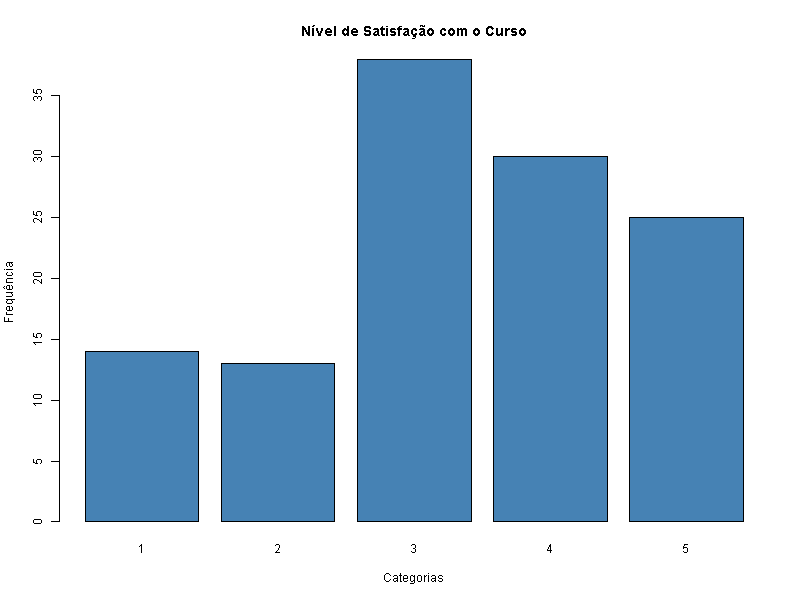

### 2.2 Distribuição de Notas e Zona de Risco

- **Metodologia:** Foi aplicada a **Regra de Sturges** para organizar o histograma e a **Ogiva de Galton** para o percentual acumulado.
- **Risco Real:** Identificamos que **46%** da turma está na zona de risco (abaixo da média 6.0).

Distribuição das Notas

Ogiva de Galton (Risco Acumulado)

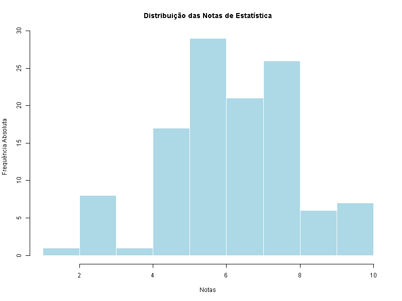

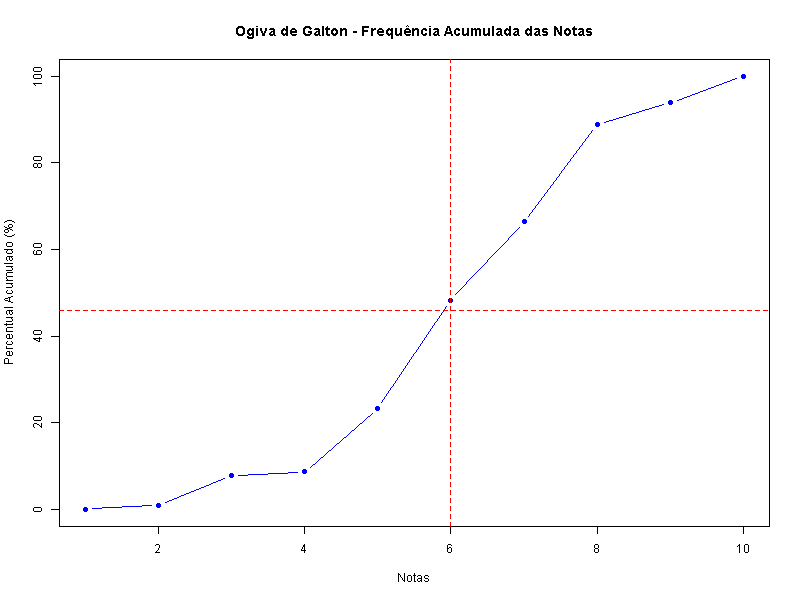

## 🔍 3. Cruzamento de Variáveis Estratégicas

### 3.1 Impacto do Trabalho e Eficácia da Monitoria

- **Trabalho vs. Nota:** Alunos que trabalham possuem média **6,12**, enquanto os que não trabalham possuem **6,29** — uma diferença de apenas 0,17 pontos.
- **Monitoria:** Frequentar a monitoria eleva a média para **6,28** (vs. **6,15**), mas apenas **34,17%** dos alunos utilizam o recurso.

Impacto do Trabalho

Eficácia da Monitoria

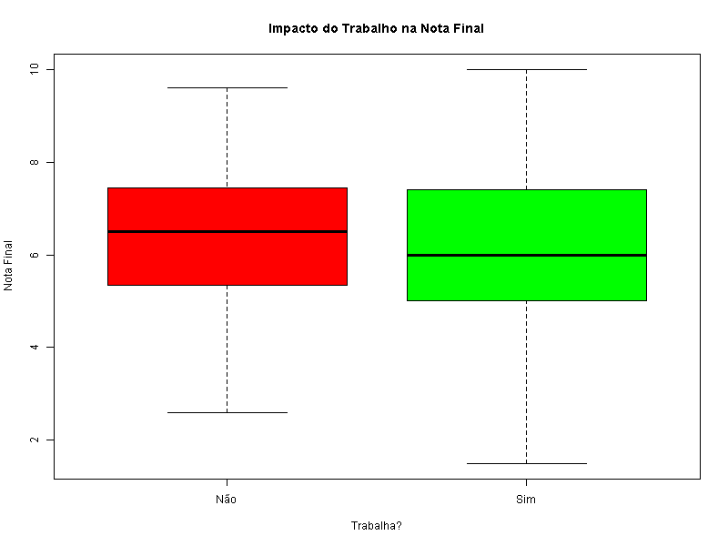

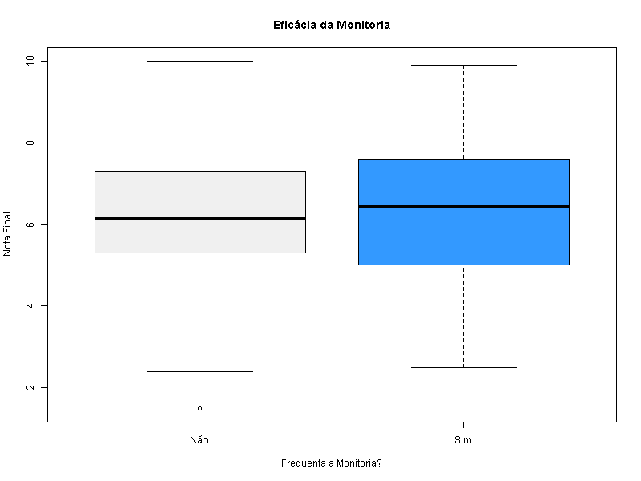

## 💡 4. Propostas de Intervenção

### 4.1 Monitoria Híbrida e Assíncrona

- **Público:** Alunos que trabalham (**58,33%**).
- **Ação:** Implementar plantões remotos e repositório de vídeos para mitigar choques de horário.

### 4.2 Programa de Engajamento Ativo

- **Público:** Alunos em risco (**46%**) e calouros.
- **Ação:** Busca ativa de alunos no primeiro quartil de notas para grupos de estudo dirigidos.

### 🛠️ Tecnologias Utilizadas

- **Linguagem:** R
- **Ambiente:** RStudio
- **Documentação:** Markdown

**Obs.:** Trabalho apresentado como requisito avaliativo na disciplina Probabilidade e Estatística, ministrada pelo Prof. Hidelbrando Ferreira Rodrigues, no Curso de Engenharia de Software do Instituto de Ciências Exatas e Tecnologia-ICET de Itacoatiara/AM, Universidade Federal do Amazonas-UFAM

**Discente**: Raul Berger de Andrade Lima